# R package

Jacob Courtney

2020-11-17

# Introduction

Congratulations for getting this far. To complete the evidence that you have made a working R package please answer the following by using the supplied rmd and upload the knitted html to CANVAS.

I will assume your package is called **MATH4753COUR0004** and you have packaged and documented functions `myci`, `myBoot`, `myncurve` and `myRandom`.

Your actual package name and functions will obviously be called something else.

# First function

Please place your first function in the r chunk in the following way:

Once you are ready please remove the option `eval = FALSE`

```r
library(MATH4753COUR0004)
y=c(3,4,5,6,7)
confidence_interval=MATH4753COUR0004:::myci(y)
confidence_interval
```

```
## [1] 3.575146 6.424854
```

# Second function

Please place your second function in the r chunk in the following way:

Once you are ready please remove the option `eval = FALSE`

```r
library(MATH4753COUR0004)
set.seed(39)
sam=rnorm(25,mean=25,sd=10)
mb=MATH4753COUR0004:::myBoot(iter=10000,x=sam,fun="mean",alpha=0.05,xlab="mean",col="red")
```

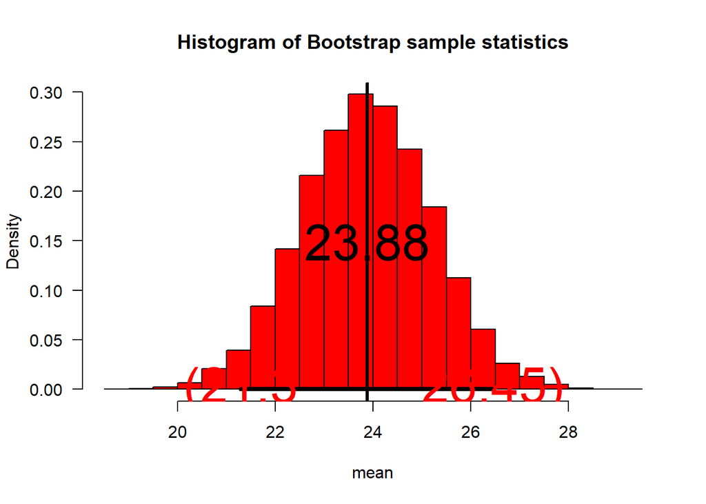

```r
mb
```

```
## $ci
##     2.5%    97.5%
## 21.29544 26.44594
##
## $fun
## [1] "mean"
##
## $x
##  [1] 23.14434 12.70757 20.72797 19.04018 29.67324 29.21639 14.78348 18.77523
##  [9] 33.37002 34.61627 26.04230 24.40206 32.03731 17.45030 19.54464 20.45388
## [17] 23.83394 30.47815 25.79640 22.67536 10.27711 26.77487 37.10044 21.59809
## [25] 22.50625
```

# Third function

Please place your third function in the r chunk in the following way:

Once you are ready please remove the option `eval = FALSE`

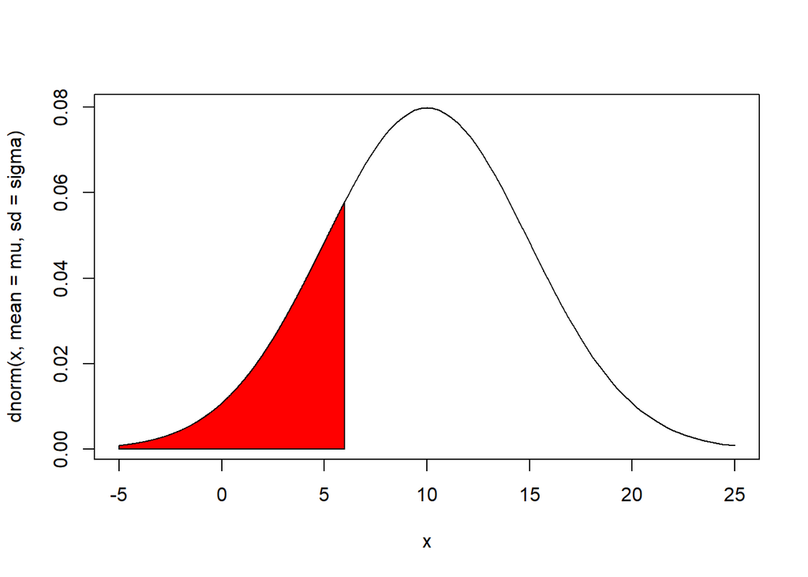

```
## [1] 0.2119
```

```r
library(MATH4753COUR0004)
MATH4753COUR0004:::myncurve(mu=10,sigma=5,a=6)
```

# Forth function

Please place your forth function in the r chunk in the following way:

Once you are ready please remove the option `eval = FALSE`

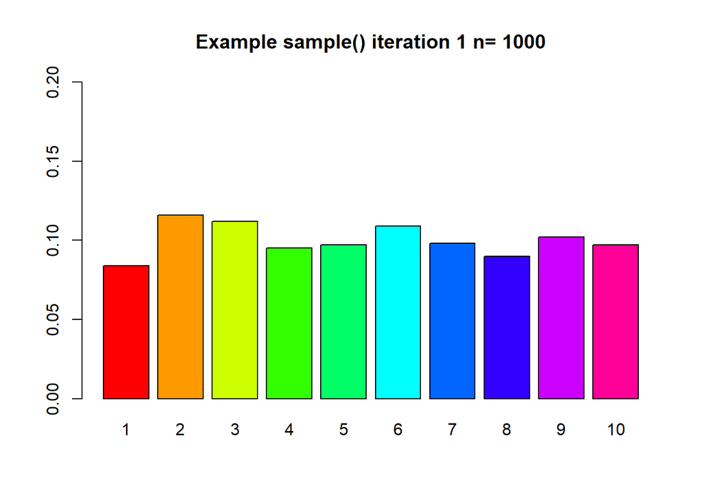

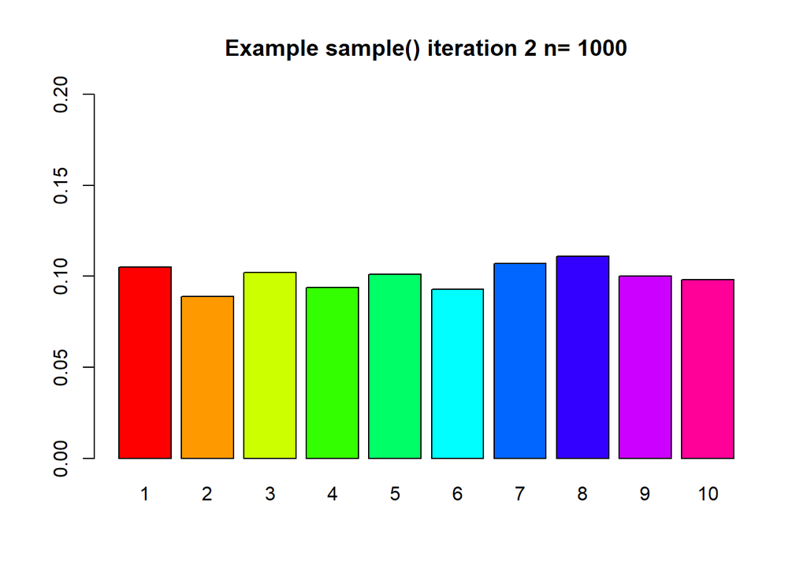

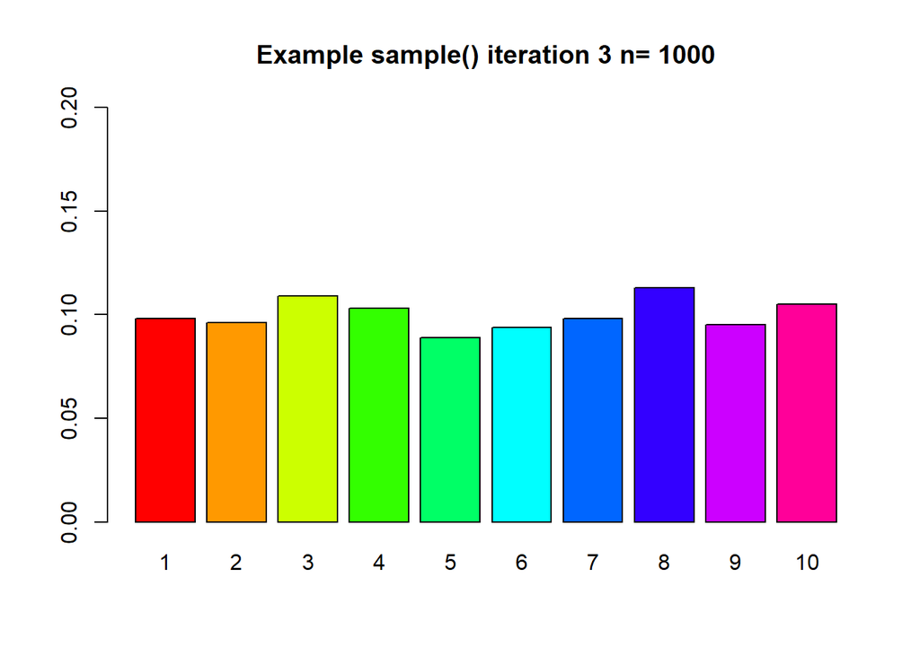

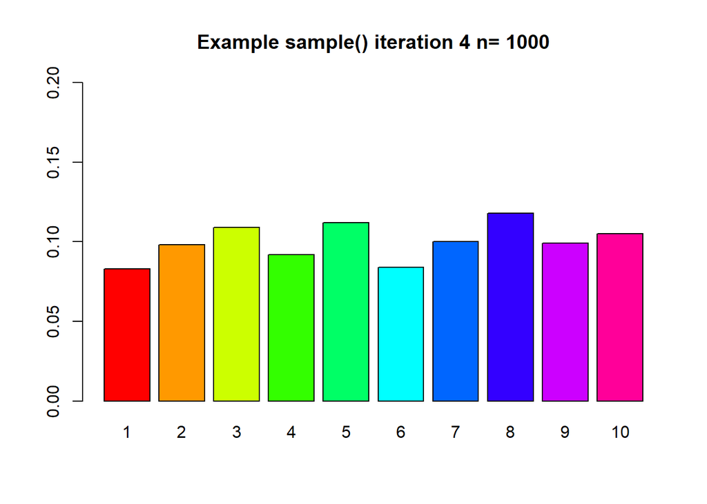

```r
MATH4753COUR0004:::myRandom(1000,4,1)
```

# The github repository

This is the address of my GITHUB repository: https://github.com/pojac3/MATH4753COUR0004.git

Replace this with your own address.